# EDA

|  | folio | fecha_creacion | hora_creacion | dia_semana | codigo_cierre | fecha_cierre | año_cierre | mes_cierre | hora_cierre | delegacion_inicio | incidente_c4 | latitud | longitud | clas_con_f_alarma | tipo_entrada | delegacion_cierre | geopoint | mes |
| --- | --- | --- | --- | --- | --- | --- | --- | --- | --- | --- | --- | --- | --- | --- | --- | --- | --- | --- |
| 566386 | C5/170511/07206 | 11/05/2017 | 22:06:07 | Jueves | (A) La unidad de atención a emergencias fue de... | 11/05/2017 | 2017 | Mayo | 22:14:09 | COYOACAN | accidente-choque sin lesionados | 19.34936 | -99.1802 | EMERGENCIA | LLAMADA DEL 911 | COYOACAN | 19.34936001,-99.18020016 | 5 |

```
1383138
```

Se tienen 1,383,138 registros de incidentes viales en la ciudad de México.

```
1383138
```

El folio efectivamente identifica a cada renglón con un valor único.

```
18
```

Se tienen 18 columnas o variables, las cuales son:

```
['folio',
 'fecha_creacion',
 'hora_creacion',
 'dia_semana',
 'codigo_cierre',
 'fecha_cierre',
 'año_cierre',
 'mes_cierre',
 'hora_cierre',
 'delegacion_inicio',
 'incidente_c4',
 'latitud',
 'longitud',
 'clas_con_f_alarma',
 'tipo_entrada',
 'delegacion_cierre',
 'geopoint',
 'mes']
```

Los tipos de dato que tiene cada variable inicialmente son:

```
folio                 object
fecha_creacion        object
hora_creacion         object
dia_semana            object
codigo_cierre         object
fecha_cierre          object
año_cierre             int64
mes_cierre            object
hora_cierre           object
delegacion_inicio     object
incidente_c4          object
latitud              float64
longitud             float64
clas_con_f_alarma     object
tipo_entrada          object
delegacion_cierre     object
geopoint              object
mes                    int64
dtype: object
```

## Perfilamiento general

```
El dataframe tiene 18 columnas.
Hay 5 columnas que tienen NA's.
```

|  | Estadísticas | Resultado |
| --- | --- | --- |
| 0 | Total de variables | 18 |
| 1 | Conteo de observaciones | 1383138 |
| 2 | Total de celdas | 24896484 |
| 3 | Cantidad de variables numéricas | 4 |
| 4 | Cantidad de variables de fecha | 0 |
| 5 | Cantidad de variables categóricas | 0 |
| 6 | Cantidad de variables de texto | 14 |
| 7 | Valores faltantes | 1622 |
| 8 | Porcentaje de valores faltantes | 0.0% |
| 9 | Renglones duplicados | 0 |
| 10 | Porcentaje de valores duplicados | 0.0% |

En la base de datos, tenemos alrededor de 1,622 elementos faltantes, distribuidos de la siguiente forma:

```
El dataframe tiene 18 columnas.
Hay 5 columnas que tienen NA's.
```

|  | Missing Values | % del Total |
| --- | --- | --- |
| geopoint | 446 | 0.0 |
| latitud | 443 | 0.0 |
| longitud | 435 | 0.0 |
| delegacion_inicio | 158 | 0.0 |
| delegacion_cierre | 140 | 0.0 |

En cuanto a los tipos de datos, están de la siguiente forma:

```
folio                 object
fecha_creacion        object
hora_creacion         object
dia_semana            object
codigo_cierre         object
fecha_cierre          object
año_cierre             int64
mes_cierre            object
hora_cierre           object
delegacion_inicio     object
incidente_c4          object
latitud              float64
longitud             float64
clas_con_f_alarma     object
tipo_entrada          object
delegacion_cierre     object
geopoint              object
mes                    int64
dtype: object
```

folio object --> Object  
fecha_creacion object --> Date  
hora_creacion object --> Date  
dia_semana object --> Category  
codigo_cierre object --> Category  
fecha_cierre object --> Date  
año_cierre int64 --> Category  
mes_cierre object --> Category  
hora_cierre object --> Date  
delegacion_inicio object --> Category  
incidente_c4 object --> Category  
latitud float64 --> float  
longitud float64 --> float  
clas_con_f_alarma object --> Category  
tipo_entrada object --> Category  
delegacion_cierre object --> Category  
geopoint object --> Object  
mes int64 --> Category

Primero, arreglamos los strings en las fechas:

```
13
14
15
16
17
18
19
20
```

|  | folio | fecha_creacion | hora_creacion | dia_semana | codigo_cierre | fecha_cierre | año_cierre | mes_cierre | hora_cierre | delegacion_inicio | incidente_c4 | latitud | longitud | clas_con_f_alarma | tipo_entrada | delegacion_cierre | geopoint | mes |
| --- | --- | --- | --- | --- | --- | --- | --- | --- | --- | --- | --- | --- | --- | --- | --- | --- | --- | --- |
| 199549 | C5/190731/07496 | 2019-07-31 | 22:09:39 | Miércoles | (A) La unidad de atención a emergencias fue de... | 2019-08-01 | 2019 | Agosto | 2:45:09 | GUSTAVO A. MADERO | accidente-choque sin lesionados | 19.50277 | -99.09382 | EMERGENCIA | LLAMADA DEL 911 | GUSTAVO A. MADERO | 19.50276996,-99.09381996 | 8 |
| 199559 | C5/190731/07697 | 2019-07-31 | 22:41:57 | Miércoles | (A) La unidad de atención a emergencias fue de... | 2019-08-01 | 2019 | Agosto | 4:09:07 | GUSTAVO A. MADERO | accidente-choque con lesionados | 19.51804 | -99.15612 | URGENCIAS MEDICAS | RADIO | GUSTAVO A. MADERO | 19.51803999,-99.15612012 | 8 |
| 199562 | C5/190731/06194 | 2019-07-31 | 19:30:49 | Miércoles | (A) La unidad de atención a emergencias fue de... | 2019-08-01 | 2019 | Agosto | 3:11:54 | VENUSTIANO CARRANZA | accidente-choque sin lesionados | 19.44261 | -99.10895 | EMERGENCIA | LLAMADA DEL 911 | VENUSTIANO CARRANZA | 19.44261,-99.10895004 | 8 |
| 199574 | C5/190731/07242 | 2019-07-31 | 21:32:45 | Miércoles | (A) La unidad de atención a emergencias fue de... | 2019-08-01 | 2019 | Agosto | 0:20:22 | IZTACALCO | accidente-choque sin lesionados | 19.38104 | -99.10895 | EMERGENCIA | LLAMADA DEL 911 | IZTAPALAPA | 19.38104001,-99.10895004 | 8 |
| 199605 | C5/190731/08080 | 2019-07-31 | 23:38:39 | Miércoles | (N) La unidad de atención a emergencias fue de... | 2019-08-01 | 2019 | Agosto | 0:21:03 | IZTACALCO | accidente-choque con lesionados | 19.41750 | -99.05641 | URGENCIAS MEDICAS | LLAMADA DEL 911 | IZTACALCO | 19.4175,-99.05640984 | 8 |
| ... | ... | ... | ... | ... | ... | ... | ... | ... | ... | ... | ... | ... | ... | ... | ... | ... | ... | ... |
| 1124425 | C5/190731/07720 | 2019-07-31 | 22:44:20 | Miércoles | (A) La unidad de atención a emergencias fue de... | 2019-08-01 | 2019 | Agosto | 1:03:00 | BENITO JUAREZ | accidente-choque sin lesionados | 19.39476 | -99.13467 | EMERGENCIA | LLAMADA DEL 911 | BENITO JUAREZ | 19.39475997,-99.13466988 | 8 |
| 1124439 | C5/190731/07272 | 2019-07-31 | 21:35:33 | Miércoles | (A) La unidad de atención a emergencias fue de... | 2019-08-01 | 2019 | Agosto | 2:18:32 | GUSTAVO A. MADERO | accidente-choque sin lesionados | 19.46464 | -99.13112 | EMERGENCIA | LLAMADA DEL 911 | GUSTAVO A. MADERO | 19.46464002,-99.13111992 | 8 |
| 1124440 | C5/190731/08112 | 2019-07-31 | 23:44:02 | Miércoles | (A) La unidad de atención a emergencias fue de... | 2019-08-01 | 2019 | Agosto | 0:35:47 | MIGUEL HIDALGO | accidente-choque con lesionados | 19.44340 | -99.17201 | URGENCIAS MEDICAS | LLAMADA APP911 | MIGUEL HIDALGO | 19.44340002,-99.17201016 | 8 |
| 1124449 | C5/190731/07578 | 2019-07-31 | 22:23:05 | Miércoles | (A) La unidad de atención a emergencias fue de... | 2019-08-01 | 2019 | Agosto | 4:48:17 | IZTAPALAPA | accidente-choque sin lesionados | 19.38177 | -99.08706 | EMERGENCIA | LLAMADA DEL 911 | IZTAPALAPA | 19.38177,-99.08705988 | 8 |
| 1124461 | C5/190731/08029 | 2019-07-31 | 23:29:56 | Miércoles | (A) La unidad de atención a emergencias fue de... | 2019-08-01 | 2019 | Agosto | 3:19:53 | ALVARO OBREGON | accidente-choque sin lesionados | 19.38949 | -99.18956 | EMERGENCIA | LLAMADA DEL 911 | ALVARO OBREGON | 19.38949002,-99.18956016 | 8 |

537 rows × 18 columns

Ahora, corregimos las horas de creación y de cierre.

```
array(['22:35:04', '22:50:49', '09:40:11', ..., '0.986863426',
       '0.996238426', '04:33:05'], dtype=object)
```

```
'0.000138889'
```

|  | folio | fecha_creacion | hora_creacion | dia_semana | codigo_cierre | fecha_cierre | año_cierre | mes_cierre | hora_cierre | delegacion_inicio | incidente_c4 | latitud | longitud | clas_con_f_alarma | tipo_entrada | delegacion_cierre | geopoint | mes |
| --- | --- | --- | --- | --- | --- | --- | --- | --- | --- | --- | --- | --- | --- | --- | --- | --- | --- | --- |
| 831339 | C5/200217/09463 | 2020-02-17 | 0.985266204 | Lunes | (A) La unidad de atención a emergencias fue de... | 2020-02-18 | 2020 | Febrero | 0.147476852 | MIGUEL HIDALGO | accidente-choque sin lesionados | 19.45393 | -99.19447 | EMERGENCIA | LLAMADA DEL 911 | MIGUEL HIDALGO | 19.45393002,-99.19446984 | 2 |
| 831341 | C5/200218/03696 | 2020-02-18 | 0.53494213 | Martes | (A) La unidad de atención a emergencias fue de... | 2020-02-18 | 2020 | Febrero | 0.592511574 | AZCAPOTZALCO | lesionado-atropellado | 19.49486 | -99.19591 | URGENCIAS MEDICAS | LLAMADA DEL 911 | AZCAPOTZALCO | 19.49486004,-99.19590984 | 2 |

```
1544
```

```
831339     0.985266204
831341      0.53494213
831343     0.366539352
831345      0.51306713
831347     0.541273148
              ...
1382352    0.921678241
1382353    0.967268519
1382354    0.976018519
1382355    0.986863426
1382356    0.996238426
Name: hora_creacion, Length: 1544, dtype: object
```

```
23:38:47.000026
```

```
23:38:47.000026
```

```
datetime.timedelta(seconds=85127, microseconds=26)
```

|  | folio | fecha_creacion | hora_creacion | dia_semana | codigo_cierre | fecha_cierre | año_cierre | mes_cierre | hora_cierre | delegacion_inicio | incidente_c4 | latitud | longitud | clas_con_f_alarma | tipo_entrada | delegacion_cierre | geopoint | mes | hora_creacion_corregida |
| --- | --- | --- | --- | --- | --- | --- | --- | --- | --- | --- | --- | --- | --- | --- | --- | --- | --- | --- | --- |
| 831339 | C5/200217/09463 | 2020-02-17 | 0.985266204 | Lunes | (A) La unidad de atención a emergencias fue de... | 2020-02-18 | 2020 | Febrero | 0.147476852 | MIGUEL HIDALGO | accidente-choque sin lesionados | 19.45393 | -99.19447 | EMERGENCIA | LLAMADA DEL 911 | MIGUEL HIDALGO | 19.45393002,-99.19446984 | 2 | 0 days 23:38:47.000026 |
| 831341 | C5/200218/03696 | 2020-02-18 | 0.53494213 | Martes | (A) La unidad de atención a emergencias fue de... | 2020-02-18 | 2020 | Febrero | 0.592511574 | AZCAPOTZALCO | lesionado-atropellado | 19.49486 | -99.19591 | URGENCIAS MEDICAS | LLAMADA DEL 911 | AZCAPOTZALCO | 19.49486004,-99.19590984 | 2 | 0 days 12:50:19.000032 |

|  | folio | fecha_creacion | hora_creacion | dia_semana | codigo_cierre | fecha_cierre | año_cierre | mes_cierre | hora_cierre | delegacion_inicio | incidente_c4 | latitud | longitud | clas_con_f_alarma | tipo_entrada | delegacion_cierre | geopoint | mes | hora_creacion_corregida |
| --- | --- | --- | --- | --- | --- | --- | --- | --- | --- | --- | --- | --- | --- | --- | --- | --- | --- | --- | --- |
| 831339 | C5/200217/09463 | 2020-02-17 | 0.985266204 | Lunes | (A) La unidad de atención a emergencias fue de... | 2020-02-18 | 2020 | Febrero | 0.147476852 | MIGUEL HIDALGO | accidente-choque sin lesionados | 19.45393 | -99.19447 | EMERGENCIA | LLAMADA DEL 911 | MIGUEL HIDALGO | 19.45393002,-99.19446984 | 2 | 0 days 23:38:47 |
| 831341 | C5/200218/03696 | 2020-02-18 | 0.53494213 | Martes | (A) La unidad de atención a emergencias fue de... | 2020-02-18 | 2020 | Febrero | 0.592511574 | AZCAPOTZALCO | lesionado-atropellado | 19.49486 | -99.19591 | URGENCIAS MEDICAS | LLAMADA DEL 911 | AZCAPOTZALCO | 19.49486004,-99.19590984 | 2 | 0 days 12:50:19 |

```
folio                               object
fecha_creacion              datetime64[ns]
hora_creacion                       object
dia_semana                          object
codigo_cierre                       object
fecha_cierre                datetime64[ns]
año_cierre                           int64
mes_cierre                          object
hora_cierre                         object
delegacion_inicio                   object
incidente_c4                        object
latitud                            float64
longitud                           float64
clas_con_f_alarma                   object
tipo_entrada                        object
delegacion_cierre                   object
geopoint                            object
mes                                  int64
hora_creacion_corregida    timedelta64[ns]
dtype: object
```

|  | folio | fecha_creacion | hora_creacion | dia_semana | codigo_cierre | fecha_cierre | año_cierre | mes_cierre | hora_cierre | delegacion_inicio | incidente_c4 | latitud | longitud | clas_con_f_alarma | tipo_entrada | delegacion_cierre | geopoint | mes | hora_creacion_corregida |
| --- | --- | --- | --- | --- | --- | --- | --- | --- | --- | --- | --- | --- | --- | --- | --- | --- | --- | --- | --- |
| 831339 | C5/200217/09463 | 2020-02-17 | 0.985266204 | Lunes | (A) La unidad de atención a emergencias fue de... | 2020-02-18 | 2020 | Febrero | 0.147476852 | MIGUEL HIDALGO | accidente-choque sin lesionados | 19.45393 | -99.19447 | EMERGENCIA | LLAMADA DEL 911 | MIGUEL HIDALGO | 19.45393002,-99.19446984 | 2 | 23:38:47 |
| 831341 | C5/200218/03696 | 2020-02-18 | 0.53494213 | Martes | (A) La unidad de atención a emergencias fue de... | 2020-02-18 | 2020 | Febrero | 0.592511574 | AZCAPOTZALCO | lesionado-atropellado | 19.49486 | -99.19591 | URGENCIAS MEDICAS | LLAMADA DEL 911 | AZCAPOTZALCO | 19.49486004,-99.19590984 | 2 | 12:50:19 |

|  | folio | fecha_creacion | hora_creacion | dia_semana | codigo_cierre | fecha_cierre | año_cierre | mes_cierre | hora_cierre | delegacion_inicio | incidente_c4 | latitud | longitud | clas_con_f_alarma | tipo_entrada | delegacion_cierre | geopoint | mes | hora_creacion_corregida |
| --- | --- | --- | --- | --- | --- | --- | --- | --- | --- | --- | --- | --- | --- | --- | --- | --- | --- | --- | --- |
| 0 | GA/160123/05714 | 2016-01-23 | 22:35:04 | Sábado | (A) La unidad de atención a emergencias fue de... | 2016-01-24 | 2016 | Enero | 00:21:08 | VENUSTIANO CARRANZA | accidente-choque sin lesionados | 19.422113 | -99.084643 | EMERGENCIA | BOTÓN DE AUXILIO | VENUSTIANO CARRANZA | 19.422113,-99.084643 | 1 | NaN |
| 1 | AO/160123/05826 | 2016-01-23 | 22:50:49 | Sábado | (A) La unidad de atención a emergencias fue de... | 2016-01-24 | 2016 | Enero | 04:40:37 | CUAJIMALPA | accidente-choque con lesionados | 19.358320 | -99.297641 | URGENCIAS MEDICAS | BOTÓN DE AUXILIO | CUAJIMALPA | 19.35832,-99.297641 | 1 | NaN |

```
array(['22:35:04', '22:50:49', '09:40:11', ..., '03:08:57', '02:05:12',
       '04:33:05'], dtype=object)
```

Repetimos el procedimiento para las horas de cierre:

|  | folio | fecha_creacion | hora_creacion | dia_semana | codigo_cierre | fecha_cierre | año_cierre | mes_cierre | hora_cierre | delegacion_inicio | incidente_c4 | latitud | longitud | clas_con_f_alarma | tipo_entrada | delegacion_cierre | geopoint | mes | hora_creacion_corregida |
| --- | --- | --- | --- | --- | --- | --- | --- | --- | --- | --- | --- | --- | --- | --- | --- | --- | --- | --- | --- |
| 831387 | C5/200218/04419 | 2020-02-18 | 14:14:33 | Martes | (N) La unidad de atención a emergencias fue de... | 2020-02-18 | 2020 | Febrero | 0.635243056 | ALVARO OBREGON | accidente-choque sin lesionados | 19.35964 | -99.209128 | EMERGENCIA | LLAMADA DEL 911 | ALVARO OBREGON | 19.35964,-99.20912778 | 2 | NaN |
| 831459 | C5/200218/02272 | 2020-02-18 | 09:49:30 | Martes | (D) El incidente reportado se registró en dos ... | 2020-02-18 | 2020 | Febrero | 0.421828704 | MIGUEL HIDALGO | lesionado-atropellado | 19.47115 | -99.206820 | URGENCIAS MEDICAS | LLAMADA APP911 | MIGUEL HIDALGO | 19.47114999,-99.20682 | 2 | NaN |

```
1542
```

```
831387     0.635243056
831459     0.421828704
831467     0.979803241
831615     0.634780093
831749     0.585763889
              ...
1382352    0.047685185
1382353    0.101643519
1382354    0.053009259
1382355    0.048530093
1382356    0.021076389
Name: hora_cierre, Length: 1542, dtype: object
```

```
23:38:47.000026
```

```
15:14:45.000038
```

```
datetime.timedelta(seconds=54885, microseconds=38)
```

|  | folio | fecha_creacion | hora_creacion | dia_semana | codigo_cierre | fecha_cierre | año_cierre | mes_cierre | hora_cierre | delegacion_inicio | incidente_c4 | latitud | longitud | clas_con_f_alarma | tipo_entrada | delegacion_cierre | geopoint | mes | hora_creacion_corregida | hora_cierre_corregida |
| --- | --- | --- | --- | --- | --- | --- | --- | --- | --- | --- | --- | --- | --- | --- | --- | --- | --- | --- | --- | --- |
| 831387 | C5/200218/04419 | 2020-02-18 | 14:14:33 | Martes | (N) La unidad de atención a emergencias fue de... | 2020-02-18 | 2020 | Febrero | 0.635243056 | ALVARO OBREGON | accidente-choque sin lesionados | 19.35964 | -99.209128 | EMERGENCIA | LLAMADA DEL 911 | ALVARO OBREGON | 19.35964,-99.20912778 | 2 | NaN | 0 days 15:14:45.000038 |
| 831459 | C5/200218/02272 | 2020-02-18 | 09:49:30 | Martes | (D) El incidente reportado se registró en dos ... | 2020-02-18 | 2020 | Febrero | 0.421828704 | MIGUEL HIDALGO | lesionado-atropellado | 19.47115 | -99.206820 | URGENCIAS MEDICAS | LLAMADA APP911 | MIGUEL HIDALGO | 19.47114999,-99.20682 | 2 | NaN | 0 days 10:07:26.000026 |

|  | folio | fecha_creacion | hora_creacion | dia_semana | codigo_cierre | fecha_cierre | año_cierre | mes_cierre | hora_cierre | delegacion_inicio | incidente_c4 | latitud | longitud | clas_con_f_alarma | tipo_entrada | delegacion_cierre | geopoint | mes | hora_creacion_corregida | hora_cierre_corregida |
| --- | --- | --- | --- | --- | --- | --- | --- | --- | --- | --- | --- | --- | --- | --- | --- | --- | --- | --- | --- | --- |
| 831387 | C5/200218/04419 | 2020-02-18 | 14:14:33 | Martes | (N) La unidad de atención a emergencias fue de... | 2020-02-18 | 2020 | Febrero | 0.635243056 | ALVARO OBREGON | accidente-choque sin lesionados | 19.35964 | -99.209128 | EMERGENCIA | LLAMADA DEL 911 | ALVARO OBREGON | 19.35964,-99.20912778 | 2 | NaN | 0 days 15:14:45 |
| 831459 | C5/200218/02272 | 2020-02-18 | 09:49:30 | Martes | (D) El incidente reportado se registró en dos ... | 2020-02-18 | 2020 | Febrero | 0.421828704 | MIGUEL HIDALGO | lesionado-atropellado | 19.47115 | -99.206820 | URGENCIAS MEDICAS | LLAMADA APP911 | MIGUEL HIDALGO | 19.47114999,-99.20682 | 2 | NaN | 0 days 10:07:26 |

```
folio                               object
fecha_creacion              datetime64[ns]
hora_creacion                       object
dia_semana                          object
codigo_cierre                       object
fecha_cierre                datetime64[ns]
año_cierre                           int64
mes_cierre                          object
hora_cierre                         object
delegacion_inicio                   object
incidente_c4                        object
latitud                            float64
longitud                           float64
clas_con_f_alarma                   object
tipo_entrada                        object
delegacion_cierre                   object
geopoint                            object
mes                                  int64
hora_creacion_corregida             object
hora_cierre_corregida      timedelta64[ns]
dtype: object
```

|  | folio | fecha_creacion | hora_creacion | dia_semana | codigo_cierre | fecha_cierre | año_cierre | mes_cierre | hora_cierre | delegacion_inicio | incidente_c4 | latitud | longitud | clas_con_f_alarma | tipo_entrada | delegacion_cierre | geopoint | mes | hora_creacion_corregida | hora_cierre_corregida |
| --- | --- | --- | --- | --- | --- | --- | --- | --- | --- | --- | --- | --- | --- | --- | --- | --- | --- | --- | --- | --- |
| 831387 | C5/200218/04419 | 2020-02-18 | 14:14:33 | Martes | (N) La unidad de atención a emergencias fue de... | 2020-02-18 | 2020 | Febrero | 0.635243056 | ALVARO OBREGON | accidente-choque sin lesionados | 19.35964 | -99.209128 | EMERGENCIA | LLAMADA DEL 911 | ALVARO OBREGON | 19.35964,-99.20912778 | 2 | NaN | 15:14:45 |
| 831459 | C5/200218/02272 | 2020-02-18 | 09:49:30 | Martes | (D) El incidente reportado se registró en dos ... | 2020-02-18 | 2020 | Febrero | 0.421828704 | MIGUEL HIDALGO | lesionado-atropellado | 19.47115 | -99.206820 | URGENCIAS MEDICAS | LLAMADA APP911 | MIGUEL HIDALGO | 19.47114999,-99.20682 | 2 | NaN | 10:07:26 |

|  | folio | fecha_creacion | hora_creacion | dia_semana | codigo_cierre | fecha_cierre | año_cierre | mes_cierre | hora_cierre | delegacion_inicio | incidente_c4 | latitud | longitud | clas_con_f_alarma | tipo_entrada | delegacion_cierre | geopoint | mes | hora_creacion_corregida | hora_cierre_corregida |
| --- | --- | --- | --- | --- | --- | --- | --- | --- | --- | --- | --- | --- | --- | --- | --- | --- | --- | --- | --- | --- |
| 0 | GA/160123/05714 | 2016-01-23 | 22:35:04 | Sábado | (A) La unidad de atención a emergencias fue de... | 2016-01-24 | 2016 | Enero | 00:21:08 | VENUSTIANO CARRANZA | accidente-choque sin lesionados | 19.422113 | -99.084643 | EMERGENCIA | BOTÓN DE AUXILIO | VENUSTIANO CARRANZA | 19.422113,-99.084643 | 1 | NaN | NaN |
| 1 | AO/160123/05826 | 2016-01-23 | 22:50:49 | Sábado | (A) La unidad de atención a emergencias fue de... | 2016-01-24 | 2016 | Enero | 04:40:37 | CUAJIMALPA | accidente-choque con lesionados | 19.358320 | -99.297641 | URGENCIAS MEDICAS | BOTÓN DE AUXILIO | CUAJIMALPA | 19.35832,-99.297641 | 1 | NaN | NaN |

```
array(['00:21:08', '04:40:37', '11:13:03', ..., '04:21:49', '02:44:31',
       '04:35:21'], dtype=object)
```

```
folio                        object
fecha_creacion       datetime64[ns]
hora_creacion                object
dia_semana                 category
codigo_cierre              category
fecha_cierre         datetime64[ns]
año_cierre                 category
mes_cierre                 category
hora_cierre                  object
delegacion_inicio          category
incidente_c4               category
latitud                     float64
longitud                    float64
clas_con_f_alarma          category
tipo_entrada               category
delegacion_cierre          category
geopoint                     object
mes                        category
dtype: object
```

### Perfilamiento por variables

|  | Métrica | latitud | longitud |
| --- | --- | --- | --- |
| 0 | Tipo | float64 | float64 |
| 1 | Número de observaciones | 1.3827e+06 | 1.3827e+06 |
| 2 | Media | 19.38 | -99.14 |
| 3 | Desviación estándar | 0.27 | 2.4 |
| 4 | Cuartil 25% | 19.34 | -99.18 |
| 5 | Cuartil 50% | 19.38 | -99.14 |
| 6 | Cuartil 75% | 19.43 | -99.1 |
| 7 | Mínimo | 19.09 | -991.76 |
| 8 | Máximo | 195.3 | -98.95 |
| 9 | Número de observaciones únicas | 82501 | 78984 |
| 10 | Número de faltantes | 443 | 435 |
| 11 | Top1/veces/% | [19.30431996, 2,173, 0.16%] | [-99.08024004, 2,162, 0.16%] |
| 12 | Top2/veces/% | [19.37168001, 2,162, 0.16%] | [-99.08714016, 2,100, 0.15%] |
| 13 | Top3/veces/% | [19.347020999999998, 1,730, 0.13%] | [-99.180646, 1,731, 0.13%] |
| 14 | Top4/veces/% | [19.35663003, 1,607, 0.12%] | [-99.08655984, 1,500, 0.11%] |
| 15 | Top5/veces/% | [19.36316997, 1,412, 0.1%] | [-99.05739984, 1,407, 0.1%] |

```
folio                 3
fecha_creacion        3
hora_creacion         3
dia_semana            3
codigo_cierre         3
fecha_cierre          3
año_cierre            3
mes_cierre            3
hora_cierre           3
delegacion_inicio     3
incidente_c4          3
latitud               3
longitud              0
clas_con_f_alarma     3
tipo_entrada          3
delegacion_cierre     3
geopoint              0
mes                   3
timestamp_creacion    3
timestamp_cierre      3
dif_solucion          3
dtype: int64
```

```
folio                 10
fecha_creacion        10
hora_creacion         10
dia_semana            10
codigo_cierre         10
fecha_cierre          10
año_cierre            10
mes_cierre            10
hora_cierre           10
delegacion_inicio     10
incidente_c4          10
latitud                0
longitud              10
clas_con_f_alarma     10
tipo_entrada          10
delegacion_cierre     10
geopoint               0
mes                   10
timestamp_creacion    10
timestamp_cierre      10
dif_solucion          10
dtype: int64
```

|  | Métrica | dia_semana | codigo_cierre | año_cierre | mes_cierre | delegacion_inicio | incidente_c4 | clas_con_f_alarma | tipo_entrada | delegacion_cierre | mes |
| --- | --- | --- | --- | --- | --- | --- | --- | --- | --- | --- | --- |
| 0 | Tipo | category | category | category | category | category | category | category | category | category | category |
| 1 | Número de categorías | 7 | 5 | 7 | 12 | 16 | 26 | 4 | 9 | 16 | 12 |
| 2 | Número de observaciones | 1383138 | 1383138 | 1383138 | 1383138 | 1383138 | 1383138 | 1383138 | 1383138 | 1383138 | 1383138 |
| 3 | Observaciones nulas | 0 | 0 | 0 | 0 | 158 | 0 | 0 | 0 | 140 | 0 |
| 4 | % Observaciones nulas | 0 | 0 | 0 | 0 | 0.000114233 | 0 | 0 | 0 | 0.000101219 | 0 |
| 5 | Valores únicos | [Sábado, Domingo, Lunes, Martes, Miércoles, Ju... | [(A) La unidad de atención a emergencias fue d... | [2016, 2017, 2018, 2019, 2015, 2014, 2020] | [Enero, Febrero, Marzo, Septiembre, Octubre, M... | [VENUSTIANO CARRANZA, CUAJIMALPA, TLALPAN, MAG... | [accidente-choque sin lesionados, accidente-ch... | [EMERGENCIA, URGENCIAS MEDICAS, FALSA ALARMA, ... | [BOTÓN DE AUXILIO, LLAMADA DEL 066, RADIO, CÁM... | [VENUSTIANO CARRANZA, CUAJIMALPA, TLALPAN, MAG... | [1, 2, 3, 9, 10, 5, 6, 4, 8, 12, 7, 11] |
| 6 | Moda1/veces/% | [Viernes, 229,681, 16.61%] | [(A) La unidad de atención a emergencias fue d... | [2018, 246,577, 17.83%] | [Octubre, 133,641, 9.66%] | [IZTAPALAPA, 223,687, 16.17%] | [accidente-choque sin lesionados, 760,506, 54.... | [EMERGENCIA, 799,037, 57.77%] | [LLAMADA DEL 911, 739,339, 53.45%] | [IZTAPALAPA, 225,202, 16.28%] | [10, 133,641, 9.66%] |
| 7 | Moda2/veces/% | [Sábado, 214,134, 15.48%] | [(D) El incidente reportado se registró en dos... | [2019, 229,467, 16.59%] | [Agosto, 121,123, 8.76%] | [GUSTAVO A. MADERO, 144,620, 10.46%] | [accidente-choque con lesionados, 315,031, 22.... | [URGENCIAS MEDICAS, 572,619, 41.4%] | [LLAMADA DEL 066, 463,432, 33.51%] | [GUSTAVO A. MADERO, 147,582, 10.67%] | [8, 121,123, 8.76%] |
| 8 | Moda3/veces/% | [Jueves, 198,147, 14.33%] | [(N) La unidad de atención a emergencias fue d... | [2017, 226,535, 16.38%] | [Septiembre, 120,581, 8.72%] | [CUAUHTEMOC, 141,391, 10.22%] | [lesionado-atropellado, 193,553, 13.99%] | [FALSA ALARMA, 10,630, 0.77%] | [BOTÓN DE AUXILIO, 78,630, 5.68%] | [CUAUHTEMOC, 141,781, 10.25%] | [9, 120,581, 8.72%] |

|  | Métrica | folio | hora_creacion | hora_cierre | geopoint |
| --- | --- | --- | --- | --- | --- |
| 0 | Tipo | object | object | object | object |
| 1 | Número de observaciones | 1383138 | 1383138 | 1383138 | 1383138 |
| 2 | Observaciones únicas | 1383138 | 104359 | 105308 | 134288 |
| 3 | % Observaciones únicas | 1 | 0.0754509 | 0.076137 | 0.0970894 |
| 4 | Tamaño promedio | 15 | 7.98064 | 7.98005 | 22.4991 |
| 5 | Tamaño mínimo | 15 | 7 | 7 | 14 |
| 6 | Tamaño máximo | 15 | 8 | 8 | 24 |

Regresar mes a numérica

|  | incidente_c4 | porcentaje |
| --- | --- | --- |
| accidente-choque sin lesionados | 760,506 | 54.98% |
| accidente-choque con lesionados | 315,031 | 22.78% |
| lesionado-atropellado | 193,553 | 13.99% |
| accidente-motociclista | 55,646 | 4.02% |
| accidente-volcadura | 31,766 | 2.3% |
| lesionado-accidente automovilístico | 6,054 | 0.44% |
| accidente-persona atrapada / desbarrancada | 5,607 | 0.41% |
| accidente-ciclista | 2,718 | 0.2% |
| accidente-otros | 2,465 | 0.18% |
| accidente-choque con prensados | 2,334 | 0.17% |
| cadáver-atropellado | 1,975 | 0.14% |
| accidente-vehiculo atrapado | 1,121 | 0.08% |
| cadáver-accidente automovilístico | 1,083 | 0.08% |
| accidente-vehículo atrapado-varado | 852 | 0.06% |
| detención ciudadana-atropellado | 702 | 0.05% |
| sismo-choque sin lesionados | 540 | 0.04% |
| accidente-vehiculo desbarrancado | 490 | 0.04% |
| sismo-choque con lesionados | 372 | 0.03% |
| detención ciudadana-accidente automovilístico | 153 | 0.01% |
| mi ciudad-calle-incidente de tránsito | 55 | 0.0% |
| accidente-ferroviario | 55 | 0.0% |
| accidente-monopatín | 31 | 0.0% |
| sismo-persona atropellada | 23 | 0.0% |
| Detención ciudadana-accidente automovilístico | 3 | 0.0% |
| sismo-choque con prensados | 2 | 0.0% |
| mi ciudad-taxi-incidente de tránsito | 1 | 0.0% |

|  | delegacion_inicio | porcentaje |
| --- | --- | --- |
| IZTAPALAPA | 223,687 | 16.17% |
| GUSTAVO A. MADERO | 144,620 | 10.46% |
| CUAUHTEMOC | 141,391 | 10.22% |
| MIGUEL HIDALGO | 115,864 | 8.38% |
| COYOACAN | 110,146 | 7.96% |
| BENITO JUAREZ | 104,322 | 7.54% |
| ALVARO OBREGON | 102,071 | 7.38% |
| VENUSTIANO CARRANZA | 94,393 | 6.82% |
| TLALPAN | 87,339 | 6.31% |
| AZCAPOTZALCO | 60,823 | 4.4% |
| IZTACALCO | 58,567 | 4.23% |
| XOCHIMILCO | 52,575 | 3.8% |
| TLAHUAC | 33,420 | 2.42% |
| CUAJIMALPA | 26,714 | 1.93% |
| MAGDALENA CONTRERAS | 20,062 | 1.45% |
| MILPA ALTA | 6,986 | 0.51% |
| NaN | 158 | 0.01% |

|  | codigo_cierre | porcentaje |
| --- | --- | --- |
| (A) La unidad de atención a emergencias fue despachada, llegó al lugar de los hechos y confirmó la emergencia reportada | 600,108 | 43.39% |
| (D) El incidente reportado se registró en dos o más ocasiones procediendo a mantener un único reporte (afirmativo, informativo, negativo o falso) como el identificador para el incidente | 495,631 | 35.83% |
| (N) La unidad de atención a emergencias fue despachada, llegó al lugar de los hechos, pero en el sitio del evento nadie solicitó el apoyo de la unidad | 271,677 | 19.64% |
| (F) El operador/a o despachador/a identifican, antes de dar respuesta a la emergencia, que ésta es falsa. O al ser despachada una unidad de atención a emergencias en el lugar de los hechos se percatan… | 10,626 | 0.77% |
| (I) El incidente reportado es afirmativo y se añade información adicional al evento | 5,096 | 0.37% |

|  | clas_con_f_alarma | porcentaje |
| --- | --- | --- |
| EMERGENCIA | 799,037 | 57.77% |
| URGENCIAS MEDICAS | 572,619 | 41.4% |
| FALSA ALARMA | 10,630 | 0.77% |
| DELITO | 852 | 0.06% |

|  | dia_semana | porcentaje |
| --- | --- | --- |
| Viernes | 229,681 | 16.61% |
| Sábado | 214,134 | 15.48% |
| Jueves | 198,147 | 14.33% |
| Miércoles | 193,857 | 14.02% |
| Martes | 189,669 | 13.71% |
| Lunes | 182,448 | 13.19% |
| Domingo | 175,202 | 12.67% |

|  | tipo_entrada | porcentaje |
| --- | --- | --- |
| LLAMADA DEL 911 | 739,339 | 53.45% |
| LLAMADA DEL 066 | 463,432 | 33.51% |
| BOTÓN DE AUXILIO | 78,630 | 5.68% |
| RADIO | 77,749 | 5.62% |
| LLAMADA APP911 | 9,483 | 0.69% |
| ZELLO | 6,451 | 0.47% |
| REDES | 4,697 | 0.34% |
| CÁMARA | 3,276 | 0.24% |
| APLICATIVOS | 81 | 0.01% |

### Creamos la variable de `timestamp`

```
Timedelta('-1 days +23:59:00')
```

```
Timedelta('397 days 03:59:16')
```

|  | folio | fecha_creacion | hora_creacion | dia_semana | codigo_cierre | fecha_cierre | año_cierre | mes_cierre | hora_cierre | delegacion_inicio | ... | latitud | longitud | clas_con_f_alarma | tipo_entrada | delegacion_cierre | geopoint | mes | timestamp_creacion | timestamp_cierre | dif_solucion |
| --- | --- | --- | --- | --- | --- | --- | --- | --- | --- | --- | --- | --- | --- | --- | --- | --- | --- | --- | --- | --- | --- |
| 865005 | C5/200313/01020 | 2020-03-13 | 04:14:20 | Viernes | (A) La unidad de atención a emergencias fue de... | 2020-03-13 | 2020 | Marzo | 04:31:03 | IZTACALCO | ... | 19.40553 | -99.07054 | URGENCIAS MEDICAS | LLAMADA DEL 911 | IZTACALCO | 19.40553,-99.07053984 | 3 | 2020-03-13 04:14:20 | 2020-03-13 04:31:03 | 0 days 00:16:43 |

1 rows × 21 columns

```
folio                                                   C5/190820/07924
fecha_creacion                                               2019-08-20
hora_creacion                                                  23:37:03
dia_semana                                                       Martes
codigo_cierre         (D) El incidente reportado se registró en dos ...
fecha_cierre                                                 2019-08-20
año_cierre                                                         2019
mes_cierre                                                       Agosto
hora_cierre                                                    23:45:10
delegacion_inicio                                            XOCHIMILCO
incidente_c4                            accidente-choque con lesionados
latitud                                                         19.2525
longitud                                                       -99.1014
clas_con_f_alarma                                     URGENCIAS MEDICAS
tipo_entrada                                            LLAMADA DEL 911
delegacion_cierre                                            XOCHIMILCO
geopoint                                       19.25245998,-99.10139004
mes                                                                   8
timestamp_creacion                                  2019-08-20 23:37:03
timestamp_cierre                                    2019-08-20 23:45:10
dif_solucion                                            0 days 00:08:07
Name: 1113029, dtype: object
```

```
Timestamp('2020-10-31 23:57:20')
```

```
Timestamp('2013-12-31 13:01:33')
```

```
array(['22:35:04', '22:50:49', '09:40:11', ..., '03:08:57', '02:05:12',
       '04:33:05'], dtype=object)
```

|  | año_cierre | porcentaje |
| --- | --- | --- |
| 2018 | 246,577 | 17.83% |
| 2019 | 229,467 | 16.59% |
| 2017 | 226,535 | 16.38% |
| 2016 | 190,996 | 13.81% |
| 2015 | 184,830 | 13.36% |
| 2014 | 171,242 | 12.38% |
| 2020 | 133,491 | 9.65% |

```
Index(['folio', 'fecha_creacion', 'hora_creacion', 'dia_semana',
       'codigo_cierre', 'fecha_cierre', 'año_cierre', 'mes_cierre',
       'hora_cierre', 'delegacion_inicio', 'incidente_c4', 'latitud',
       'longitud', 'clas_con_f_alarma', 'tipo_entrada', 'delegacion_cierre',
       'geopoint', 'mes', 'timestamp_creacion', 'timestamp_cierre',
       'dif_solucion'],
      dtype='object')
```

|  | incidente_c4 | porcentaje |
| --- | --- | --- |
| accidente-choque sin lesionados | 760,506 | 54.98% |
| accidente-choque con lesionados | 315,031 | 22.78% |
| lesionado-atropellado | 193,553 | 13.99% |
| accidente-motociclista | 55,646 | 4.02% |
| accidente-volcadura | 31,766 | 2.3% |
| lesionado-accidente automovilístico | 6,054 | 0.44% |
| accidente-persona atrapada / desbarrancada | 5,607 | 0.41% |
| accidente-ciclista | 2,718 | 0.2% |
| accidente-otros | 2,465 | 0.18% |
| accidente-choque con prensados | 2,334 | 0.17% |
| cadáver-atropellado | 1,975 | 0.14% |
| accidente-vehiculo atrapado | 1,121 | 0.08% |
| cadáver-accidente automovilístico | 1,083 | 0.08% |
| accidente-vehículo atrapado-varado | 852 | 0.06% |
| detención ciudadana-atropellado | 702 | 0.05% |
| sismo-choque sin lesionados | 540 | 0.04% |
| accidente-vehiculo desbarrancado | 490 | 0.04% |
| sismo-choque con lesionados | 372 | 0.03% |
| detención ciudadana-accidente automovilístico | 153 | 0.01% |
| mi ciudad-calle-incidente de tránsito | 55 | 0.0% |
| accidente-ferroviario | 55 | 0.0% |
| accidente-monopatín | 31 | 0.0% |
| sismo-persona atropellada | 23 | 0.0% |
| Detención ciudadana-accidente automovilístico | 3 | 0.0% |
| sismo-choque con prensados | 2 | 0.0% |
| mi ciudad-taxi-incidente de tránsito | 1 | 0.0% |

# GEDA

## Generando etiqueta

```
0    1100835
1     282303
Name: label, dtype: int64
```

## Definiendo funciones, opciones y variables a usar en gráficas

## `CODIGO_DE_CIERRE`

### Frecuencia códigos de cierre

|  | counts |
| --- | --- |
| (A) La unidad de atención a emergencias fue despachada, llegó al lugar de los hechos y confirmó la emergencia reportada | 600108 |
| (D) El incidente reportado se registró en dos o más ocasiones procediendo a mantener un único reporte (afirmativo, informativo, negativo o falso) como el identificador para el incidente | 495631 |
| (N) La unidad de atención a emergencias fue despachada, llegó al lugar de los hechos, pero en el sitio del evento nadie solicitó el apoyo de la unidad | 271677 |
| (F) El operador/a o despachador/a identifican, antes de dar respuesta a la emergencia, que ésta es falsa. O al ser despachada una unidad de atención a emergencias en el lugar de los hechos se percatan… | 10626 |
| (I) El incidente reportado es afirmativo y se añade información adicional al evento | 5096 |

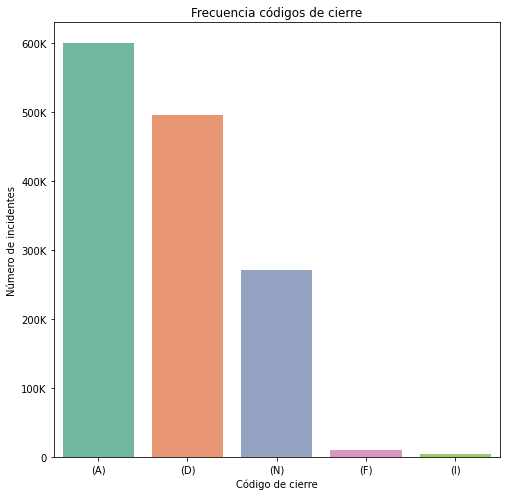

## `LABEL`

|  | counts |
| --- | --- |
| 0 | 1100835 |
| 1 | 282303 |

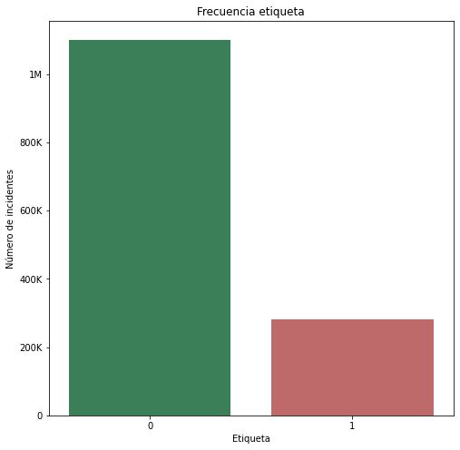

### Etiqueta por delegación

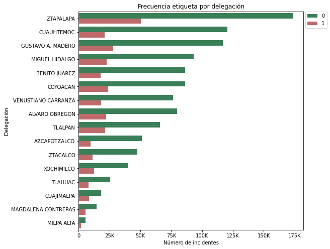

### Etiqueta por día

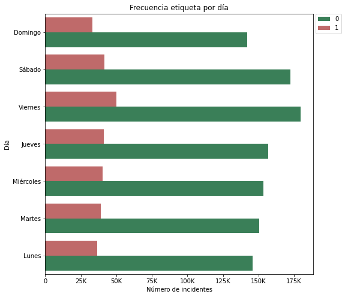

### Etiqueta por mes

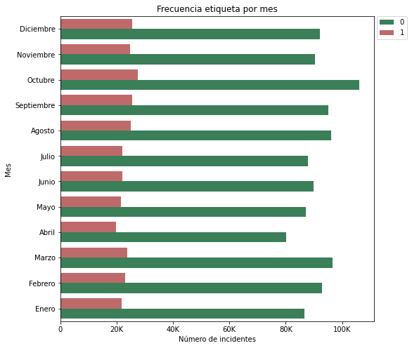

### Etiqueta por año

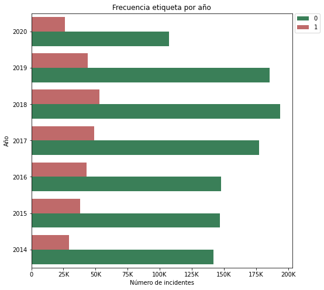

### Etiqueta por `clas_con_f_alarma`

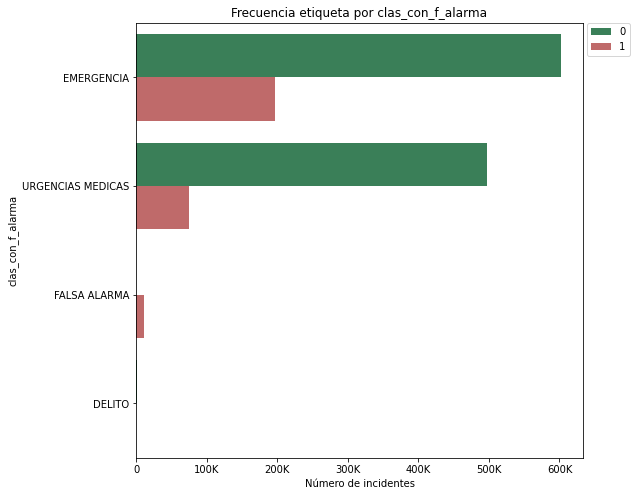

### Comparando misma delegación de inicio y cierre

|  | counts |
| --- | --- |
| Sí | 1339316 |
| No | 43822 |

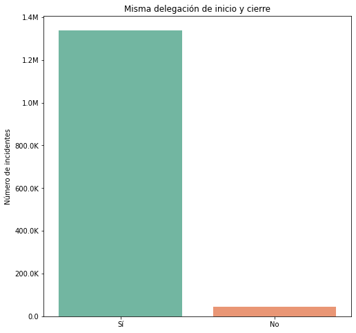

### Etiqueta en el mapa

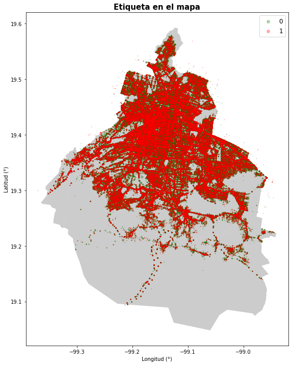

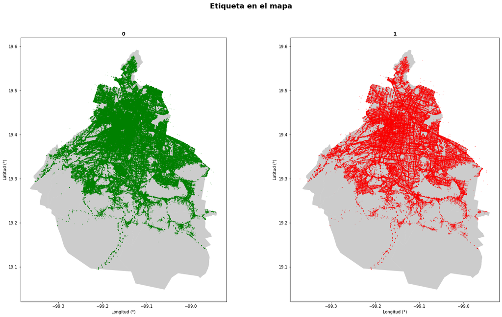

### Etiqueta por Tipo de entrada

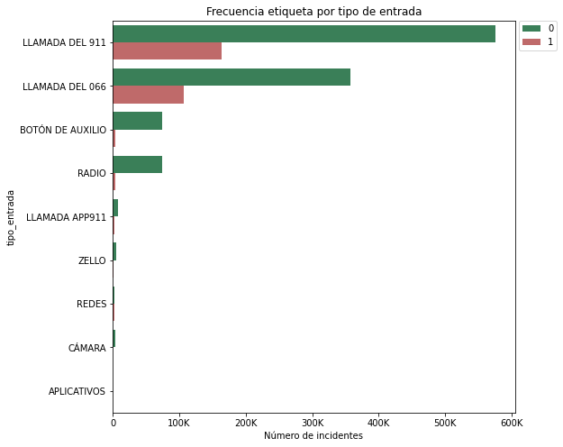